# Atividade 05

Benilton Carvalho

6/3/2020

## Atividade 05 - COVID-19 na Região de Campinas e Estado de SP

- Estado de SP
- Região Metropolitana de Campinas (RMC)
- Região Metropolitana de Campinas (RMC) + Piracicaba + Limeira: municípios atendidos por *campi* da UNICAMP
- Municípios da RMC

Para carregar os dados, você precisará utilizar o pacote `tidyverse`, como sugerido abaixo:

```r
library(tidyverse)
load("../dados/spdata.rda")
```

[output not shown]

Para obter dados de um município, você pode aplicar filtros utilizando a coluna `city`. Por exemplo, para os casos e óbitos ocorridos em Jundiaí:

```r
spdata %>% filter(city == "Jundiaí") %>% head() %>%  knitr::kable()
```

| date | city | place_type | confirmed | deaths | estimated_population_2019 |
| --- | --- | --- | --- | --- | --- |
| 2020-03-25 | Jundiaí | city | 1 | 0 | 418962 |
| 2020-03-26 | Jundiaí | city | 2 | 0 | 418962 |
| 2020-03-27 | Jundiaí | city | 3 | 0 | 418962 |
| 2020-03-30 | Jundiaí | city | 3 | 0 | 418962 |
| 2020-03-31 | Jundiaí | city | 3 | 0 | 418962 |
| 2020-04-01 | Jundiaí | city | 5 | 0 | 418962 |

Estas informações podem ser utilizadas para compor os gráficos de casos e óbitos acumulados:

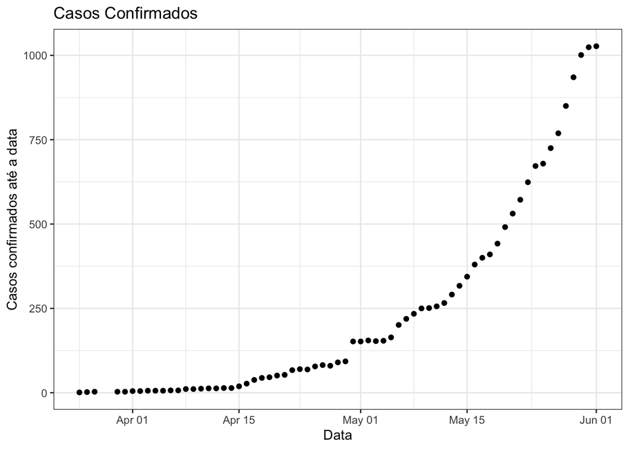

```r
library(ggplot2)
spdata %>% filter(city == "Jundiaí") %>%
  ggplot(aes(date, confirmed)) + geom_point() + theme_bw() +
  xlab("Data") + ylab("Casos confirmados até a data") + ggtitle("Casos Confirmados")
```

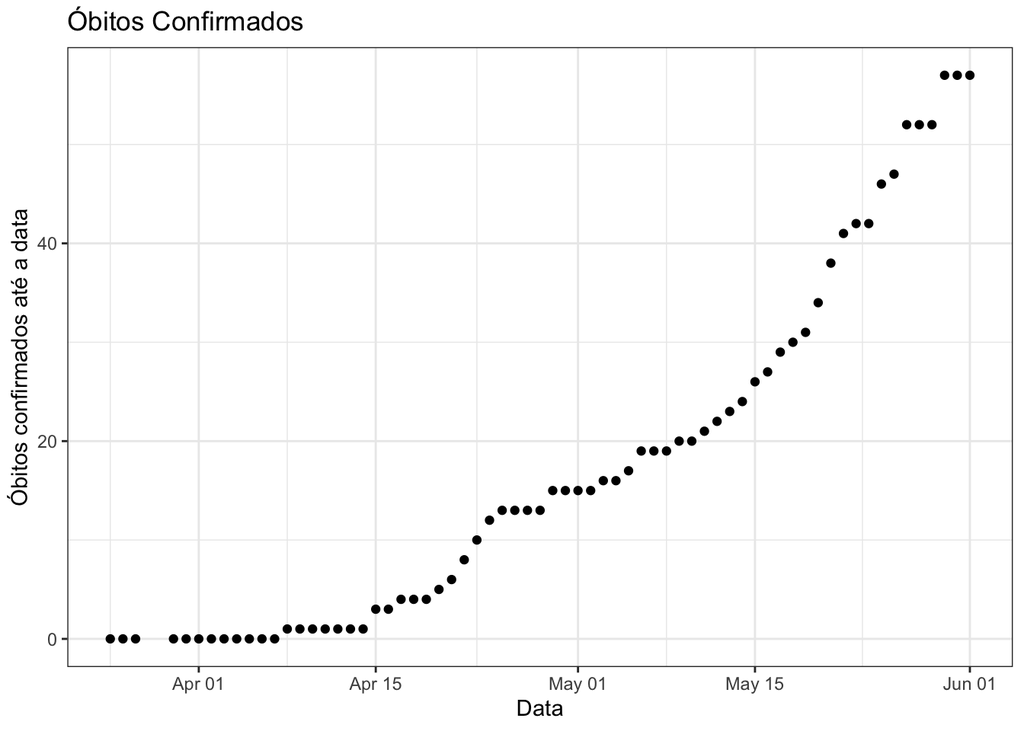

```r
spdata %>% filter(city == "Jundiaí") %>%
  ggplot(aes(date, deaths)) + geom_point() + theme_bw() +
  xlab("Data") + ylab("Óbitos confirmados até a data") + ggtitle("Óbitos Confirmados")
```

## Questões

1. Escolha três municípios (ou regiões) de interesse;
2. Apresente um modelo de regressão para *casos acumulados* para cada uma das escolhas acima;
3. Apresente um modelo de regressão para *óbitos acumulados* para cada uma das escolhas acima;
4. Apresente um modelo de regressão para *casos diários* para cada uma das escolhas acima;
5. Apresente um modelo de regressão para *óbitos diários* para cada uma das escolhas acima;
6. Apresente o código necessário para a realização de todas as atividades aqui descritas.